# Prosper Loan Data Exploration & Analysis

# Structure of the Dataset

This data set contains 113,937 loans with 81 variables on each loan, including loan amount, borrower rate (or interest rate), current loan status, borrower income, and many others. The vast majority of the 81 variables are quantitative.

A breakdown of the different of what each column variable represents can be found at the following link: https://docs.google.com/spreadsheets/d/1gDyi_L4UvIrLTEC6Wri5nbaMmkGmLQBk-Yx3z0XDEtI/edit#gid=0

## Initial Data Wrangling

# Loan Status

## Are the majority of borrowers in good or bad standing on their loan payments?

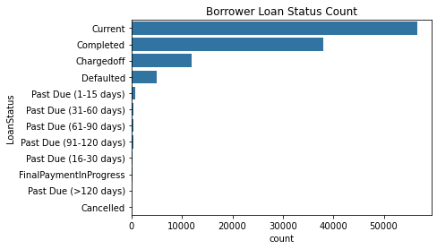

# Credit Grade

Credit grades are particularly important for lenders in determining a borrowers credit worthiness and how much credit should be extended to an individual. I want to see what the credit grade breakdown is like amongst prosper loan borrowers.

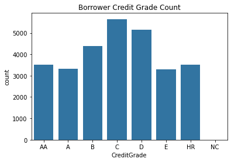

# Borrower State

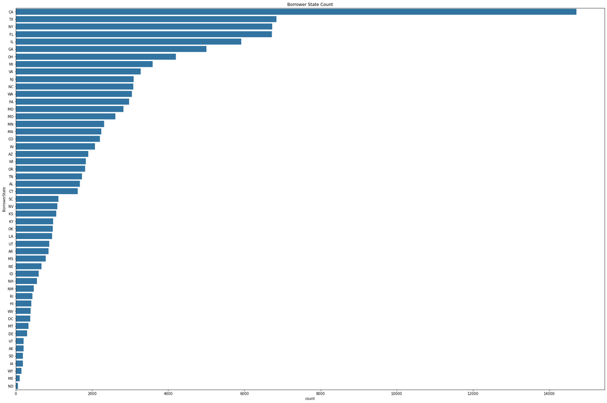

The majority of borrowers reside in the states of California, Texas, New York, Florida, and Illinois, in that order. There isn't a concentration of borrowers from a specific region in the United States like say the pacific northwest, the north east, or mid-atlantic. They hail from all states situated all across the United States.

# Employment Status

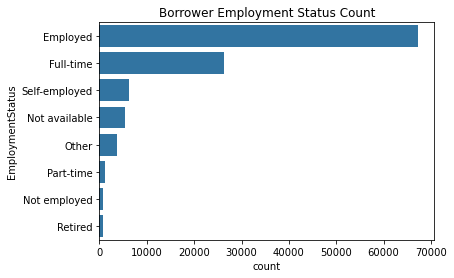

## Univariate Key Takeaways

Although the range of original loan amounts varied from \$1,000 USD to \\$35,000 USD on average borrowers had original loan amounts of \$8,337 USD and the most frequent original loan amount was \\$4,000 USD.

The most common monthly loan payment amount is \$173.71 USD and the average amounts to \\$272.45 USD.

In the case of borrower APR the most common APR was 35% while the average and median APRs amounted to 21%.

As for the amount of time that prosper loans had attached for maturity there were three timeframes: 12, 36, and 60 months. 77% of borrowers had loan term timeframes of 36 months.

The average amount of open revolving credit accounts borrowers had at the time of their credit report being pulled for a propser loan was 7, the median was 6, and the mode was 5.

The average revolving credit balance was \$17,598 USD while the most common value was \\$0.

On average, the stated monthly income of all borrowers was \$5,608 and the median amounted to \\$4,666. Interestingly enough, the range was quite large, with some borrowers reporting no monthly income and others as high \$1.75 million.

Debt-to-income ratios across all borrowers on average amounted to 27.6\% and a median value of 22%. The high levels of debt by some borrowers, as high as 10 times their income pulls the average up. However, the most frequent debt-to-income ratio amounted to .18 or 18%.

In the case of the total prosper loans that borrowers had just over 90% of borrowers either 1 or 2 loans. 70% had 1 loan while 20% had 2.

Bank card utilization peaked at a maximum of 5.95 while averaging .56 across all borrowers. The most common value however was 0, indicating borrowers either had no current utilization or no credit.

And in the case of prosper scores, scores ranging from 4 to 8 comprised over 67\% of all prosper scores across all borrowers within a range of 1-10. A small subset of borrowers were improperly marked with a value greater than prosper score rating system allows for.

## Question #2: What factors affect a loan’s outcome status?

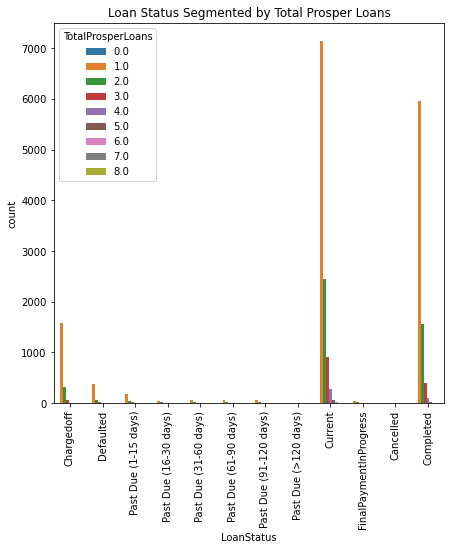

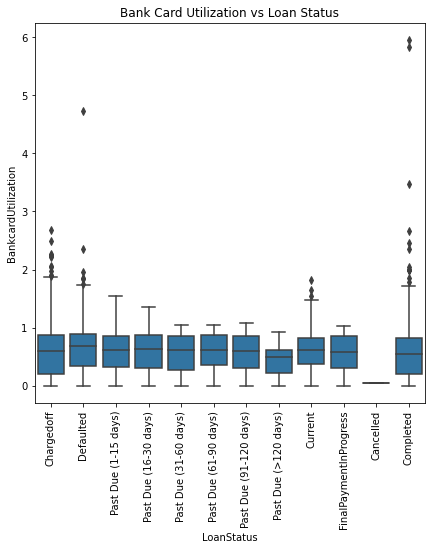

### Observation

The only association with loan status that stood out amongst the rest is bank card utilization. The distribution for loans that resulted in default is quite similar to the rest in the plot. However, loans that resulted in default saw bank card utilizations as high as almost 5 for some borrowers. Surprisingly, the same is true of loans that resulted in completion, with an upper limit for bank card utilization that was as high as 6.

However, the box plots for this relationship depict that outliers are the cause for this. The box plots also show that the the quartiles for each of the loan status categories are very much around the same levels.

There may be patterns between loan status and the non-numeric/categorical variables.

I'll go ahead and explore those as well.

## Question #3: What factors most affect a borrower’s APR or interest rate?

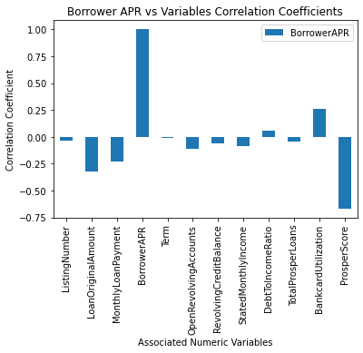

### Observation

Out of all the variables I've selected, ProsperScore, LoanOriginalAmount, BankcardUtilization, and MonthlyLoanPayment have the most impact on BorrowerAPR, in that order respectively.

ProsperScore has a strong negative correlation with BorrowerAPR. The higher a borrowers prosper score the lower their loan APR would be.

LoanOriginalAmount has a relatively weaker negative correlation with BorrowerAPR than ProsperScore, with a pearson correlation value that's almost half the amount of ProsperScore. The higher the original loan amount was the lower the APR tends to be.

BankcardUtilization has a moderate positive correlation with BorrowerAPR. Borrowers that had greater bank card utilization saw higher APRs in general.

MonthlyLoanPayment, much like LoanOriginalAmount, is negatively correlated with BorrowerAPR; borrowers with higher monthly loan payments generally had lower APRs on their loans.

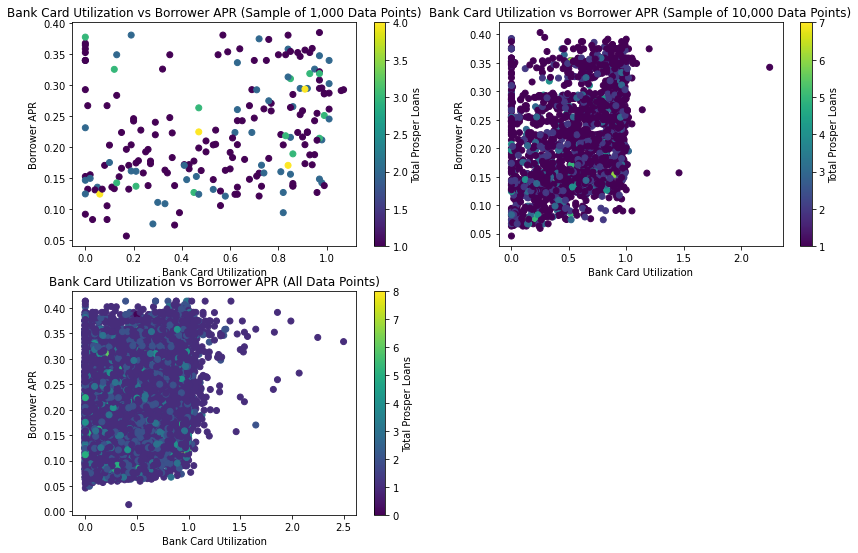

### Observation

Based on previous plots the interaction between BorrowerAPR and BankcardUtilization is positive, in that the higher a borrower's bank card utilization at the time of a credit report pull, the higher their APR will be. I used two varying sample sizes for the first two plots to depict a visual that was less crowded by all of the points. The last plot however depicts an extremely dense concentration of points within the range of 0 to 1 for bank card utilization. With more clear values and outliers further to the right in the overall distribution.

In previous assessments it was shown that the vast majority fall within the range of 0 to 1 for bank card utilization. Essentially indicating that prosper loans were given to individuals all along that spectrum.

In conjuction with previous assessment, these scatter plots serve as further confirmation that the vast majority of borrowers had zero to 2 prosper loans, with 1 prosper loan being the most common prosper loan amount (the mode).